# Data Analytics Coursework_1 (ECS784P)

# Surya Chandra Selvaraj - 210383171

### Telecom Chrun rate prediction using supervised learning machine learning methods

The customer churn rate means the number of customers leaving the company or withdrawing from the service provided by the company. We have used supervised learning machine learning methods to predict this rate of users/customers leaving the services provided by the telecommunication company.

```python
import pandas as pd                     # library for data manipulation and analysis
import numpy as np                      # library for high-level mathematical functions
import seaborn as sns                   # visualisation library for plotting with advanced features
from matplotlib import pyplot as plt    # visualisation library used for plotting
%matplotlib inline
```

```python
df = pd.read_csv('Customer-Churn.csv',index_col=False) # loading the CSV data set into a dataFrame name df
```

```python
df.columns # returns all the column names in the dataframe df
```

```
Index(['customerID', 'gender', 'SeniorCitizen', 'Partner', 'Dependents',
       'tenure', 'PhoneService', 'MultipleLines', 'InternetService',
       'OnlineSecurity', 'OnlineBackup', 'DeviceProtection', 'TechSupport',
       'StreamingTV', 'StreamingMovies', 'Contract', 'PaperlessBilling',
       'PaymentMethod', 'MonthlyCharges', 'TotalCharges', 'Churn'],
      dtype='object')
```

```python
df.head() # returns the first 5 lines of the dataframe
```

|  | customerID | gender | SeniorCitizen | Partner | Dependents | tenure | PhoneService | MultipleLines | InternetService | OnlineSecurity | ... | DeviceProtection | TechSupport | StreamingTV | StreamingMovies | Contract | PaperlessBilling | PaymentMethod | MonthlyCharges | TotalCharges | Churn |
| --- | --- | --- | --- | --- | --- | --- | --- | --- | --- | --- | --- | --- | --- | --- | --- | --- | --- | --- | --- | --- | --- |
| 0 | 7590-VHVEG | Female | 0 | Yes | No | 1 | No | No phone service | DSL | No | ... | No | No | No | No | Month-to-month | Yes | Electronic check | 29.85 | 29.85 | No |
| 1 | 5575-GNVDE | Male | 0 | No | No | 34 | Yes | No | DSL | Yes | ... | Yes | No | No | No | One year | No | Mailed check | 56.95 | 1889.50 | No |
| 2 | 3668-QPYBK | Male | 0 | No | No | 2 | Yes | No | DSL | Yes | ... | No | No | No | No | Month-to-month | Yes | Mailed check | 53.85 | 108.15 | Yes |
| 3 | 7795-CFOCW | Male | 0 | No | No | 45 | No | No phone service | DSL | Yes | ... | Yes | Yes | No | No | One year | No | Bank transfer (automatic) | 42.30 | 1840.75 | No |
| 4 | 9237-HQITU | Female | 0 | No | No | 2 | Yes | No | Fiber optic | No | ... | No | No | No | No | Month-to-month | Yes | Electronic check | 70.70 | 151.65 | Yes |

5 rows × 21 columns

```python
df.tail() # returns the last 5 lines of the dataframe
```

|  | customerID | gender | SeniorCitizen | Partner | Dependents | tenure | PhoneService | MultipleLines | InternetService | OnlineSecurity | ... | DeviceProtection | TechSupport | StreamingTV | StreamingMovies | Contract | PaperlessBilling | PaymentMethod | MonthlyCharges | TotalCharges | Churn |
| --- | --- | --- | --- | --- | --- | --- | --- | --- | --- | --- | --- | --- | --- | --- | --- | --- | --- | --- | --- | --- | --- |
| 7038 | 6840-RESVB | Male | 0 | Yes | Yes | 24 | Yes | Yes | DSL | Yes | ... | Yes | Yes | Yes | Yes | One year | Yes | Mailed check | 84.80 | 1990.50 | No |
| 7039 | 2234-XADUH | Female | 0 | Yes | Yes | 72 | Yes | Yes | Fiber optic | No | ... | Yes | No | Yes | Yes | One year | Yes | Credit card (automatic) | 103.20 | 7362.90 | No |
| 7040 | 4801-JZAZL | Female | 0 | Yes | Yes | 11 | No | No phone service | DSL | Yes | ... | No | No | No | No | Month-to-month | Yes | Electronic check | 29.60 | 346.45 | No |
| 7041 | 8361-LTMKD | Male | 1 | Yes | No | 4 | Yes | Yes | Fiber optic | No | ... | No | No | No | No | Month-to-month | Yes | Mailed check | 74.40 | 306.60 | Yes |
| 7042 | 3186-AJIEK | Male | 0 | No | No | 66 | Yes | No | Fiber optic | Yes | ... | Yes | Yes | Yes | Yes | Two year | Yes | Bank transfer (automatic) | 105.65 | 6844.50 | No |

5 rows × 21 columns

```python
df.dtypes # returns the datatype of each column in the dataframe
```

```
customerID           object
gender               object
SeniorCitizen         int64
Partner              object
Dependents           object
tenure                int64
PhoneService         object
MultipleLines        object
InternetService      object
OnlineSecurity       object
OnlineBackup         object
DeviceProtection     object
TechSupport          object
StreamingTV          object
StreamingMovies      object
Contract             object
PaperlessBilling     object
PaymentMethod        object
MonthlyCharges      float64
TotalCharges        float64
Churn                object
dtype: object
```

```python
df.shape # returns the shape of data rows and column respectively
```

```
(7043, 21)
```

```python
df['Churn'].value_counts() # return a series containing counts of unique rows in the dataframe df
```

```
No     5174
Yes    1869
Name: Churn, dtype: int64
```

### Pre-processing the data set

```python
df = df.drop(['customerID'],axis=1) # drop the customerID column because it is useless for prediction
```

```python
df.describe() #function computes a summary of statistics pertaining to the DataFrame columns
```

|  | SeniorCitizen | tenure | MonthlyCharges | TotalCharges |
| --- | --- | --- | --- | --- |
| count | 7043.000000 | 7043.000000 | 7043.000000 | 7043.00000 |
| mean | 0.162147 | 32.371149 | 64.761692 | 2281.77900 |
| std | 0.368612 | 24.559481 | 30.090047 | 2265.42947 |
| min | 0.000000 | 0.000000 | 18.250000 | 18.80000 |
| 25% | 0.000000 | 9.000000 | 35.500000 | 402.22500 |
| 50% | 0.000000 | 29.000000 | 70.350000 | 1397.30000 |
| 75% | 0.000000 | 55.000000 | 89.850000 | 3786.60000 |
| max | 1.000000 | 72.000000 | 118.750000 | 8684.80000 |

```python
df.info() #prints information about the dataframe
```

```
<class 'pandas.core.frame.DataFrame'>
RangeIndex: 7043 entries, 0 to 7042
Data columns (total 20 columns):
 #   Column            Non-Null Count  Dtype
---  ------            --------------  -----
 0   gender            7043 non-null   object
 1   SeniorCitizen     7043 non-null   int64
 2   Partner           7043 non-null   object
 3   Dependents        7043 non-null   object
 4   tenure            7043 non-null   int64
 5   PhoneService      7043 non-null   object
 6   MultipleLines     7043 non-null   object
 7   InternetService   7043 non-null   object
 8   OnlineSecurity    7043 non-null   object
 9   OnlineBackup      7043 non-null   object
 10  DeviceProtection  7043 non-null   object
 11  TechSupport       7043 non-null   object
 12  StreamingTV       7043 non-null   object
 13  StreamingMovies   7043 non-null   object
 14  Contract          7043 non-null   object
 15  PaperlessBilling  7043 non-null   object
 16  PaymentMethod     7043 non-null   object
 17  MonthlyCharges    7043 non-null   float64
 18  TotalCharges      7043 non-null   float64
 19  Churn             7043 non-null   object
dtypes: float64(2), int64(2), object(16)
memory usage: 1.1+ MB
```

```python
df.dtypes #returns all the columns with corresponding datatypes
```

```
gender               object
SeniorCitizen         int64
Partner              object
Dependents           object
tenure                int64
PhoneService         object
MultipleLines        object
InternetService      object
OnlineSecurity       object
OnlineBackup         object
DeviceProtection     object
TechSupport          object
StreamingTV          object
StreamingMovies      object
Contract             object
PaperlessBilling     object
PaymentMethod        object
MonthlyCharges      float64
TotalCharges        float64
Churn                object
dtype: object
```

```python
df.isnull().sum() #returns the sum of null values of every column
```

```
gender              0
SeniorCitizen       0
Partner             0
Dependents          0
tenure              0
PhoneService        0
MultipleLines       0
InternetService     0
OnlineSecurity      0
OnlineBackup        0
DeviceProtection    0
TechSupport         0
StreamingTV         0
StreamingMovies     0
Contract            0
PaperlessBilling    0
PaymentMethod       0
MonthlyCharges      0
TotalCharges        0
Churn               0
dtype: int64
```

```python
#Removing any  missing values in the dataframe even though if the spaces are as string
df = df.dropna(how='any')
```

### Exploratory Data Analysis

```python
df.head() #returns the top 5 rows in the dataframe
```

|  | gender | SeniorCitizen | Partner | Dependents | tenure | PhoneService | MultipleLines | InternetService | OnlineSecurity | OnlineBackup | DeviceProtection | TechSupport | StreamingTV | StreamingMovies | Contract | PaperlessBilling | PaymentMethod | MonthlyCharges | TotalCharges | Churn |
| --- | --- | --- | --- | --- | --- | --- | --- | --- | --- | --- | --- | --- | --- | --- | --- | --- | --- | --- | --- | --- |
| 0 | Female | 0 | Yes | No | 1 | No | No phone service | DSL | No | Yes | No | No | No | No | Month-to-month | Yes | Electronic check | 29.85 | 29.85 | No |
| 1 | Male | 0 | No | No | 34 | Yes | No | DSL | Yes | No | Yes | No | No | No | One year | No | Mailed check | 56.95 | 1889.50 | No |
| 2 | Male | 0 | No | No | 2 | Yes | No | DSL | Yes | Yes | No | No | No | No | Month-to-month | Yes | Mailed check | 53.85 | 108.15 | Yes |
| 3 | Male | 0 | No | No | 45 | No | No phone service | DSL | Yes | No | Yes | Yes | No | No | One year | No | Bank transfer (automatic) | 42.30 | 1840.75 | No |
| 4 | Female | 0 | No | No | 2 | Yes | No | Fiber optic | No | No | No | No | No | No | Month-to-month | Yes | Electronic check | 70.70 | 151.65 | Yes |

```python
df.tail() #returns the last 5 rows in the dataframe
```

|  | gender | SeniorCitizen | Partner | Dependents | tenure | PhoneService | MultipleLines | InternetService | OnlineSecurity | OnlineBackup | DeviceProtection | TechSupport | StreamingTV | StreamingMovies | Contract | PaperlessBilling | PaymentMethod | MonthlyCharges | TotalCharges | Churn |
| --- | --- | --- | --- | --- | --- | --- | --- | --- | --- | --- | --- | --- | --- | --- | --- | --- | --- | --- | --- | --- |
| 7038 | Male | 0 | Yes | Yes | 24 | Yes | Yes | DSL | Yes | No | Yes | Yes | Yes | Yes | One year | Yes | Mailed check | 84.80 | 1990.50 | No |
| 7039 | Female | 0 | Yes | Yes | 72 | Yes | Yes | Fiber optic | No | Yes | Yes | No | Yes | Yes | One year | Yes | Credit card (automatic) | 103.20 | 7362.90 | No |
| 7040 | Female | 0 | Yes | Yes | 11 | No | No phone service | DSL | Yes | No | No | No | No | No | Month-to-month | Yes | Electronic check | 29.60 | 346.45 | No |
| 7041 | Male | 1 | Yes | No | 4 | Yes | Yes | Fiber optic | No | No | No | No | No | No | Month-to-month | Yes | Mailed check | 74.40 | 306.60 | Yes |
| 7042 | Male | 0 | No | No | 66 | Yes | No | Fiber optic | Yes | No | Yes | Yes | Yes | Yes | Two year | Yes | Bank transfer (automatic) | 105.65 | 6844.50 | No |

```python
df['gender'].value_counts() # returns the count of male and female in the column gender
```

```
Male      3555
Female    3488
Name: gender, dtype: int64
```

```python
df['gender'].value_counts(normalize=True) # returns the normalized value count
```

```
Male      0.504756
Female    0.495244
Name: gender, dtype: float64
```

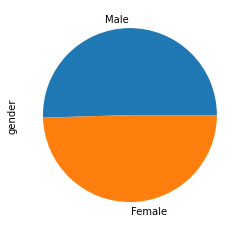

```python
df['gender'].value_counts().plot.pie() #Plot as pie-chart
```

We can infer from the pie chart that the number of male and female in the dataset is approximately 50 percent each.

```python
df['SeniorCitizen'].value_counts() #returns the count of senior citizens 0 indicating false and 1 is true
```

```
0    5901
1    1142
Name: SeniorCitizen, dtype: int64
```

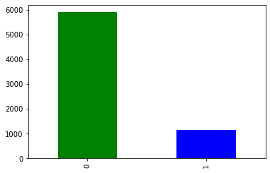

```python
df['SeniorCitizen'].value_counts().plot(kind='bar', color=['g','b']) # this plots the distribution of Senior Citizen
```

The number of senior citizen is 1142 compared to adults whose count is 5901.

```python
df['Dependents'].value_counts() #returns the count of dependents
```

```
No     4933
Yes    2110
Name: Dependents, dtype: int64
```

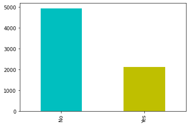

```python
df['Dependents'].value_counts().plot(kind='bar',color=['c','y']) # this plots the distribution of dependents
```

The number of customers who have dependents is 2110 and others who do not have dependents is 4933.

```
No                  3390
Yes                 2971
No phone service     682
Name: MultipleLines, dtype: int64
```

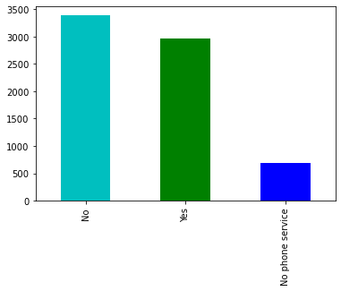

```python
df['MultipleLines'].value_counts().plot(kind='bar', color=['c','g','b']) # this plots the distribution of network connections
df['MultipleLines'].value_counts()
```

The number of customers with multiple line connections is 2971 and those who do not is 3390, and no phone service is 682.

```
Fiber optic    3096
DSL            2421
No             1526
Name: InternetService, dtype: int64
```

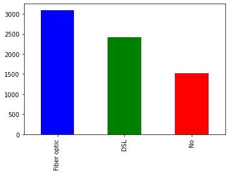

```python
df['InternetService'].value_counts().plot(kind='bar', color=['b','g','r']) # this plots the distribution of fiber optic, DSL and No connections
df['InternetService'].value_counts()
```

The number of customers with fiber optic connections is 3096, DSL is 2421 and no internet connection is 1526.

```
No                     3498
Yes                    2019
No internet service    1526
Name: OnlineSecurity, dtype: int64
```

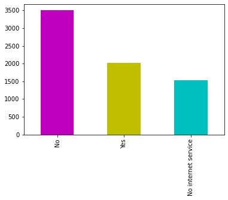

```python
df['OnlineSecurity'].value_counts().plot(kind='bar', color=['m','y','c']) # this plots the distribution of online security
df['OnlineSecurity'].value_counts()
```

The number of customers opted for online security is 2019, not-opted is 3498 and no internet service is 1526.

```
No                     3088
Yes                    2429
No internet service    1526
Name: OnlineBackup, dtype: int64
```

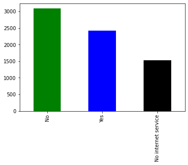

```python
df['OnlineBackup'].value_counts().plot(kind='bar', color=['g','b','k']) # this plots the distribution of online backup
df['OnlineBackup'].value_counts()
```

The number of customers opted for online backup is 2429, not-opted is 3088 and no internet service is 1526.

```
No                     2810
Yes                    2707
No internet service    1526
Name: StreamingTV, dtype: int64
```

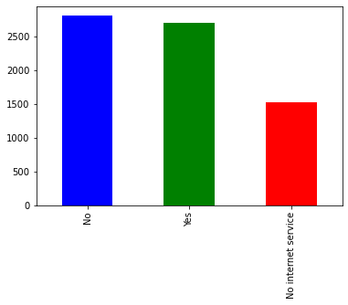

```python
df['StreamingTV'].value_counts().plot(kind='bar', color=['b','g','r']) # this plots the distribution of streamingTV
df['StreamingTV'].value_counts()
```

The number of customers streaming TV is 2707, not-streaming TV is 2810 and no internet service is 1526.

```
No                     2785
Yes                    2732
No internet service    1526
Name: StreamingMovies, dtype: int64
```

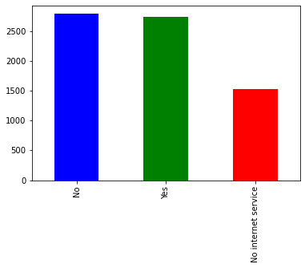

```python
df['StreamingMovies'].value_counts().plot(kind='bar', color=['b','g','r']) # this plots the distribution of StreamingMovies
df['StreamingMovies'].value_counts()
```

The number of customers streaming movies is 2732, not-streaming TV is 2785 and no internet service is 1526.

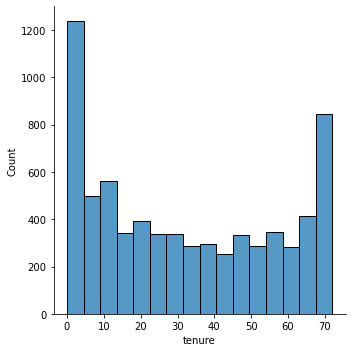

```python
sns.displot(df['tenure']) # Similarly, we can visualise the distribution of the numerical variables of tenure
plt.show()
```

The bar plot depicts the tenure years with the number of customers. We can infer that 0 to 5 month contract is higher than all the tenure segments.

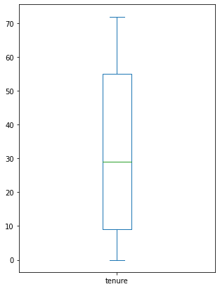

```python
df['tenure'].plot.box(figsize=(5,7)) # Creates a box plot with five-number summary
plt.show()
```

This box plot for tenure shows the high,low,1st quartile, median quartile and the 3rd quartile. Median lies around tenure 30 months.

```
Yes    6361
No      682
Name: PhoneService, dtype: int64
```

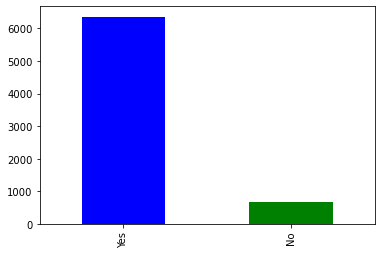

```python
df['PhoneService'].value_counts().plot(kind='bar', color=['b','g'],) # this plots the distribution of users with phone service
df['PhoneService'].value_counts()
```

The number of customers who have opted for phone service is 6361 and those who are not is 682.

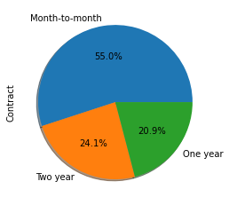

```python
df['Contract'].value_counts().plot(kind='pie',shadow = True,autopct='%1.1f%%') # this pie plots the distribution of contract on a pie chart
```

The number of customers who have opted for month-to-month tenure percentage is 55, one-year is 20.9 and two-year is 24.1 percent.

```
Yes    4171
No     2872
Name: PaperlessBilling, dtype: int64
```

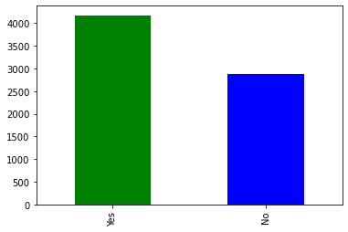

```python
df['PaperlessBilling'].value_counts().plot(kind='bar',color=['g','b']) # this plots the distribution of paperlessbilling
df['PaperlessBilling'].value_counts()
```

The number of customers who have opted for paperless billing is 4171 and those who are not is 2872.

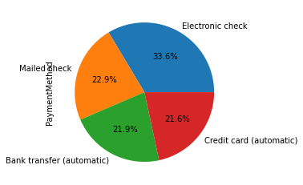

```python
df['PaymentMethod'].value_counts().plot(kind='pie',autopct='%1.1f%%') # this plots the distribution of payment method
```

The payment method opted by most customers is electronic check and the least is credit card method of payment.

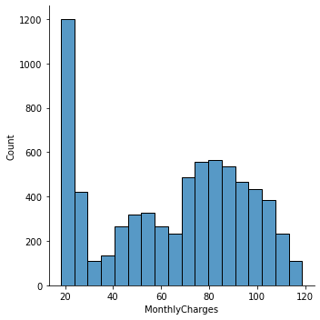

```python
sns.displot(df['MonthlyCharges']) # distribution of monthly charges from 20 to 120 unit cash
plt.show()
```

The count of units of monthly charges vs customers depicts that most customers most customers pay 20 to 25 units of cash .

```
No     5174
Yes    1869
Name: Churn, dtype: int64
```

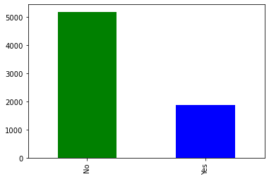

```python
df['Churn'].value_counts().plot(kind='bar',color=['g','b']) # this plots the distribution of the target value churn
df['Churn'].value_counts()
```

This bar chart depicts the number of users that leave the service which is 1869 and those who do not is 5174

### Bivariate Analysis

#### Categorical Independent Variable vs Target Variable

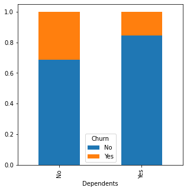

```python
Dependents=pd.crosstab(df['Dependents'],df['Churn']) #matrix format that displays the frequency distribution of the variables here dependents vs churn
Dependents.div(Dependents.sum(1).astype(float), axis=0).plot(kind="bar",stacked=True,figsize=(5,5)) #normalize the table
plt.show()
```

The bar chart shows normalized bars of number of dependents vs churn rate. we can infer that those who do not have dependents has the major losing customer compared to those with dependents.

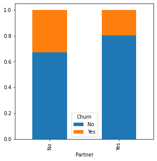

```python
Partner=pd.crosstab(df['Partner'],df['Churn']) # matrix format that displays the frequency distribution of the variables here partner vs churn
Partner.div(Partner.sum(1).astype(float), axis=0).plot(kind="bar",stacked=True,figsize=(5,5)) # normalize the table
plt.show()
```

The bar chart shows normalized bars of number of partner vs churn rate. we can note that those without partners has the highest churn rate compared to those who are without the partners.

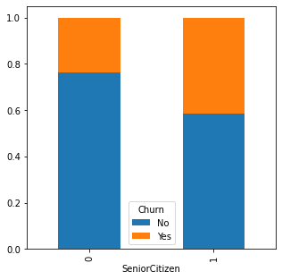

```python
SeniorCitizen=pd.crosstab(df['SeniorCitizen'],df['Churn']) # matrix format that displays the frequency distribution of the variables here SeniorCitizen vs churn
SeniorCitizen.div(SeniorCitizen.sum(1).astype(float), axis=0).plot(kind="bar",stacked=True,figsize=(5,5)) # normalize the table
plt.show()
```

The bar chart shows normalized bars of number of senior citizen vs churn rate. we can note that those who fall in to the senior citizen category has the highest churn rate.

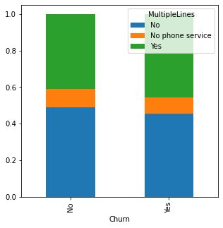

```python
MultipleLines=pd.crosstab(df['Churn'],df['MultipleLines']) # matrix format that displays the frequency distribution of the variables here multiplesLines vs churn
MultipleLines.div(MultipleLines.sum(1).astype(float), axis=0).plot(kind="bar",stacked=True,figsize=(5,5)) # normalize the table
plt.show()
```

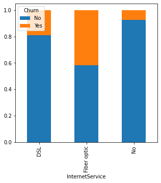

```python
InternetService=pd.crosstab(df['InternetService'],df['Churn']) #matrix format that displays the frequency distribution of the variables here InternetService vs churn
InternetService.div(InternetService.sum(1).astype(float), axis=0).plot(kind="bar",stacked=True,figsize=(5,5)) # normalize the table
plt.show()
```

The bar chart shows normalized bars of type of internet service opted vs churn rate. Those customers who has opted for fiber optic internet service might be experiencing few problems and thus that particular segment has the highest churn rate.

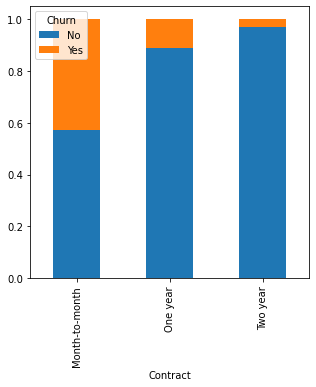

```python
Contract=pd.crosstab(df['Contract'],df['Churn']) # matrix format that displays the frequency distribution of the variables contract and churn
Contract.div(Contract.sum(1).astype(float), axis=0).plot(kind="bar",stacked=True,figsize=(5,5)) # normalize the table
plt.show()
```

Here, those who took month-to-month contract has the highest churn rate since they are not bound by any contracts after a month and can switch to other services easily.

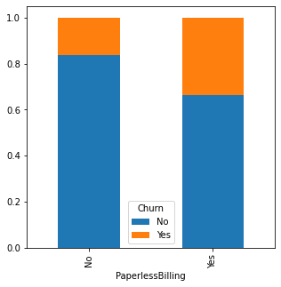

```python
PaperlessBilling=pd.crosstab(df['PaperlessBilling'],df['Churn']) #matrix format that displays the frequency distribution of the variables paperlessBilling and churn
PaperlessBilling.div(PaperlessBilling.sum(1).astype(float), axis=0).plot(kind="bar",stacked=True,figsize=(5,5)) # normalize the table
plt.show()
```

Here paperless billing has the highest churn rate than other billings.

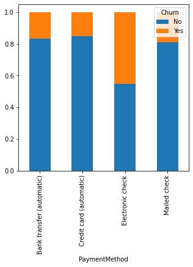

```python
PaymentMethod=pd.crosstab(df['PaymentMethod'],df['Churn']) # matrix format that displays the frequency distribution of the variables paymentmethod and churn
PaymentMethod.div(PaymentMethod.sum(1).astype(float), axis=0).plot(kind="bar",stacked=True,figsize=(5,5)) # normalize the table
plt.show()
```

Here electronic check method of payment has the highest churn rate and credit card automatic has the least churn rate.